# LNBI Markdown

John Barrera & Marta Avalos

2026-01-18

```r
library(tidyverse)
library(igraph)
library(glmmTMB)
library(magrittr)
library(vegan)
library(qgraph)
library(patchwork)
library(knitr)
library(DT)
```

# Part 1: Data sources

There are three data sources used for the analysis of the *COBRA-ENV2* study: *Bacteria Counts*, *Fungi Counts*, and *Meta Data*.

The *Bacteria Counts* and *Fungi Counts* datasets contain sequencing counts and total counts for 967 bacterial taxa (genus level or higher) and 3,709 fungal taxa (species level or higher), respectively, across 62 individual samples. The *Meta Data* dataset contains individual-level covariates, including clinical status (case = asthmatic; control = healthy). All three data sources are stored in the *COBRA-ENV2.RData* file.

```r
load("COBRA-ENV2.RData")
```

# Part 2: Proportion data and filters

The first step is transform the sequence counts to proportion data, dividing by the total number of sequence counts per sample, and then filtering the bacterial and fungal taxa, according to the following criteria:

- **Presence:** the taxon is present in at least 5% of the samples, where it registers a value greater than zero;
- **Abundance:** the proportion data for the taxon exceed 1% at least in one sample.

```r
dat.bact.mod<-dat.clin %>%
  left_join(dat.bact %>%
              column_to_rownames("Sample") %>%
              transmute(across(where(is.numeric),~.x/TotalCount)) %>%
              select(-TotalCount) %>%
              dplyr::select(where(~is.numeric(.x) & mean(.x>0)>=0.05 & max(.x)>=0.01)) %>%
              rownames_to_column("Sample"),join_by(Sample))

dat.fung.mod<-dat.clin %>%
  left_join(dat.fung %>%
              column_to_rownames("Sample") %>%
              transmute(across(where(is.numeric),~.x/TotalCount)) %>%
              select(-TotalCount) %>%
              dplyr::select(where(~is.numeric(.x) & mean(.x>0)>=0.05 & max(.x)>=0.01)) %>%
              rownames_to_column("Sample"),join_by(Sample))

# Taxa for analysis

taxa.bact<-colnames(dat.bact.mod)[(dim(dat.clin)[2]+1):(dim(dat.bact.mod)[2])]
taxa.fung<-colnames(dat.fung.mod)[(dim(dat.clin)[2]+1):(dim(dat.fung.mod)[2])]
```

After this step, 101 bacteria genus and 139 fungi species remain for the next part.

# Part 3: Descriptive analysis: table one and diversity plots

## Table One

```r
library(gtsummary)
library(dplyr)
vars <- c("Sex", "AgeGroup", "Mold", "Zone", "ForestationRate",
          "Humidity2", "Air_Quality", "PollenGroup")

tbl <- dat.clin %>%
  select(Asthma, all_of(vars)) %>%
  tbl_summary(
    by = Asthma,
    missing = "no",
    statistic = all_categorical() ~ "{n} ({p}%)",
    type = all_categorical() ~ "categorical"
  ) %>%
  add_overall() %>%
  add_p

tbl
```

| **Characteristic** | **Overall** N = 62<sup>1</sup> | **No** N = 20<sup>1</sup> | **Yes** N = 42<sup>1</sup> | **p-value**<sup>2</sup> |
| --- | --- | --- | --- | --- |
| Sex |  |  |  | >0.9 |
| Female | 40 (65%) | 13 (65%) | 27 (64%) |  |
| Male | 22 (35%) | 7 (35%) | 15 (36%) |  |
| AgeGroup |  |  |  | 0.002 |
| Less than 60 | 35 (56%) | 17 (85%) | 18 (43%) |  |
| More than 60 | 27 (44%) | 3 (15%) | 24 (57%) |  |
| Mold |  |  |  | 0.4 |
| No | 54 (87%) | 16 (80%) | 38 (90%) |  |
| Yes | 8 (13%) | 4 (20%) | 4 (9.5%) |  |
| Zone |  |  |  | 0.016 |
| Rural | 26 (42%) | 4 (20%) | 22 (52%) |  |
| Urban | 36 (58%) | 16 (80%) | 20 (48%) |  |
| ForestationRate |  |  |  | 0.5 |
| High | 14 (23%) | 3 (15%) | 11 (26%) |  |
| Low | 48 (77%) | 17 (85%) | 31 (74%) |  |
| Humidity2 |  |  |  | 0.7 |
| High | 21 (34%) | 6 (30%) | 15 (36%) |  |
| Low | 41 (66%) | 14 (70%) | 27 (64%) |  |
| Air_Quality |  |  |  | 0.010 |
| High | 39 (63%) | 8 (40%) | 31 (74%) |  |
| Low | 23 (37%) | 12 (60%) | 11 (26%) |  |
| PollenGroup |  |  |  | 0.023 |
| High | 52 (84%) | 20 (100%) | 32 (76%) |  |
| Low | 10 (16%) | 0 (0%) | 10 (24%) |  |

<sup>1</sup> n (%)  
<sup>2</sup> Pearson’s Chi-squared test; Fisher’s exact test

## Bacteria diversity plots

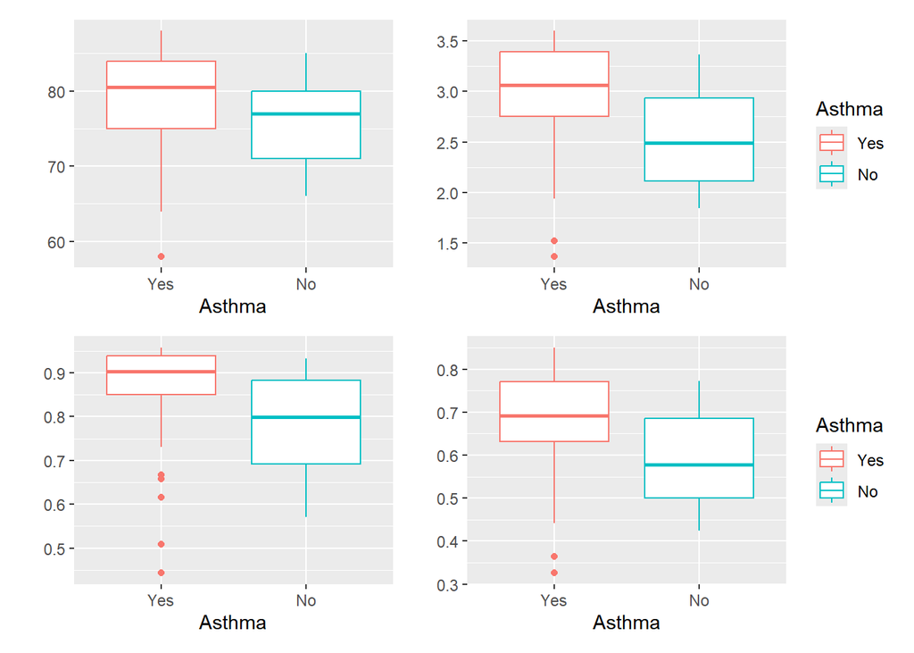

```r
dat.bact.div<-dat.bact %>% column_to_rownames("Sample") %>% dplyr::select(all_of(taxa.bact))

# Chao1

bact.div.chao1<-specnumber(dat.bact.div) %>%
  as.data.frame() %>%
  set_names("Chao1") %>%
  rownames_to_column("Sample")

# Shannon

bact.div.shannon<-diversity(dat.bact.div,index="shannon") %>%
  as.data.frame() %>%
  set_names("Shannon") %>%
  rownames_to_column("Sample")

# Simpson

bact.div.simpson<-diversity(dat.bact.div,index="simpson") %>%
  as.data.frame() %>%
  set_names("Simpson") %>%
  rownames_to_column("Sample")

# Diversity dataframe and Pielou index computation

dat.bact.div<-bact.div.shannon %>%
  left_join(bact.div.simpson) %>%
  left_join(bact.div.chao1) %>%
  mutate(Pielou=Shannon/log(Chao1)) %>%
  left_join(dat.clin[,c(1,4)],join_by(Sample)) %>%
  mutate(Asthma=factor(Asthma,levels=c("Yes","No")))

# Diversity boxplots

# Chao1

bg1<-dat.bact.div %>%
  ggplot(aes(x=Asthma,colour = Asthma))+
  geom_boxplot(aes(y=Chao1))+
  ylab("")+
  theme(legend.position = "none")

# Shannon

bg2<-dat.bact.div %>%
  ggplot(aes(x=Asthma,colour = Asthma))+
  geom_boxplot(aes(y=Shannon))+
  ylab("")

# Simpson

bg3<-dat.bact.div %>%
  ggplot(aes(x=Asthma,colour = Asthma))+
  geom_boxplot(aes(y=Simpson))+
  ylab("")+
  theme(legend.position = "none")

# Pielou

bg4<-dat.bact.div %>%
  ggplot(aes(x=Asthma,colour = Asthma))+
  geom_boxplot(aes(y=Pielou))+
  ylab("")

# Main figure

(bg1+bg2)/(bg3+bg4)
```

## Fungi diversity plots

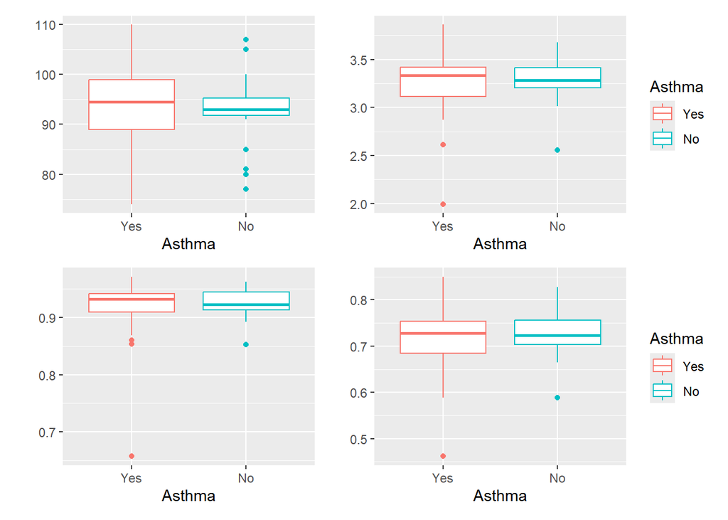

```r
dat.fung.div<-dat.fung %>% column_to_rownames("Sample") %>% dplyr::select(all_of(taxa.fung))

# Chao1

fung.div.chao1<-specnumber(dat.fung.div) %>%
  as.data.frame() %>%
  set_names("Chao1") %>%
  rownames_to_column("Sample")

# Shannon

fung.div.shannon<-diversity(dat.fung.div,index="shannon") %>%
  as.data.frame() %>%
  set_names("Shannon") %>%
  rownames_to_column("Sample")

# Simpson

fung.div.simpson<-diversity(dat.fung.div,index="simpson") %>%
  as.data.frame() %>%
  set_names("Simpson") %>%
  rownames_to_column("Sample")

# Diversity dataframe and Pielou index computation

dat.fung.div<-fung.div.shannon %>%
  left_join(fung.div.simpson) %>%
  left_join(fung.div.chao1) %>%
  mutate(Pielou=Shannon/log(Chao1)) %>%
  left_join(dat.clin[,c(1,4)],join_by(Sample)) %>%
  mutate(Asthma=factor(Asthma,levels=c("Yes","No")))

# Diversity boxplots

# Chao1

fg1<-dat.fung.div %>%
  ggplot(aes(x=Asthma,colour = Asthma))+
  geom_boxplot(aes(y=Chao1))+
  ylab("")+
  theme(legend.position = "none")

# Shannon

fg2<-dat.fung.div %>%
  ggplot(aes(x=Asthma,colour = Asthma))+
  geom_boxplot(aes(y=Shannon))+
  ylab("")

# Simpson

fg3<-dat.fung.div %>%
  ggplot(aes(x=Asthma,colour = Asthma))+
  geom_boxplot(aes(y=Simpson))+
  ylab("")+
  theme(legend.position = "none")

# Pielou

fg4<-dat.fung.div %>%
  ggplot(aes(x=Asthma,colour = Asthma))+
  geom_boxplot(aes(y=Pielou))+
  ylab("")

# Main figure

(fg1+fg2)/(fg3+fg4)
```

# Part 4: DAA: models for asthma significance

1. **Fixed effects:** model with fixed effects for all covariates (individual and environmental) in both abundance and presence (if necessary).
2. **Mixed effects:** model with fixed effects for individual covariates, and a random intercept grouped by the geographical cluster, both in abundance and presence parts (if necessary).

## DAA (bacteria)

```r
# Covariates for the 3 specifications

covar0<-c("Asthma")
covar1<-c("Asthma","Sex","AgeGroup","ForestationRate","Zone","Humidity","Air_Quality","PollenGroup","Mold")
covar2<-c("Asthma","Sex","AgeGroup","Mold")
```

## Crude model (bacteria)

```r
# Cycle 0: crude model

models.crude<-list()
taxa.crude<-c()

for(type in taxa.bact)
{
  #type="01D2Z36"
  y<-pull(dat.bact.mod,type)
  if(mean(y>0)<=0.8)
  {
    tabmod<-dat.bact.mod %>%
      dplyr::select(Sample,contains(type),all_of(covar0))
    form<-reformulate(c("1",covar0),as.name(type))
    form1<-formula(paste(" ",paste(covar0,collapse=" + "),sep=" ~ "))
    mod<-try(glmmTMB(form,data=tabmod,family=beta_family(link="logit"),ziformula = form1),silent=T)
    flag<-((!is.nan(coef(summary(mod))$cond["AsthmaYes",4]) & coef(summary(mod))$cond["AsthmaYes",4]<0.05) |
             (!is.nan(coef(summary(mod))$zi["AsthmaYes",4]) & coef(summary(mod))$zi["AsthmaYes",4]<0.05))
  }
  else
  {
    tabmod<-dat.bact.mod %>%
      dplyr::select(Sample,contains(type),all_of(covar0)) %>%
      mutate(across(contains(type),~ifelse(.x==0,1e-9,.x)))
    form<-reformulate(c("1",covar0),as.name(type))
    mod<-try(glmmTMB(form,data=tabmod,family=beta_family(link="logit")),silent=T)
    flag<-(!is.nan(coef(summary(mod))$cond["AsthmaYes",4]) & coef(summary(mod))$cond["AsthmaYes",4]<0.05)
  }
  models.crude[[type]]<-mod
  if(flag) taxa.crude<-c(taxa.crude,type)
}
```

With this model 17 significant bacterial taxa.

## Fixed effects model (bacteria)

```r
# Cycle 1: fixed effects model

models.fixed<-list()
taxa.fixed<-c()

for(type in taxa.bact)
{
  #type="01D2Z36"
  y<-pull(dat.bact.mod,type)
  if(mean(y>0)<=0.8)
  {
    tabmod<-dat.bact.mod %>%
      dplyr::select(Sample,contains(type),all_of(covar1))
    form<-reformulate(c("1",covar1),as.name(type))
    form1<-formula(paste(" ",paste(covar1,collapse=" + "),sep=" ~ "))
    mod<-try(glmmTMB(form,data=tabmod,family=beta_family(link="logit"),ziformula = form1),silent=T)
    flag<-((!is.nan(coef(summary(mod))$cond["AsthmaYes",4]) & coef(summary(mod))$cond["AsthmaYes",4]<0.05) |
             (!is.nan(coef(summary(mod))$zi["AsthmaYes",4]) & coef(summary(mod))$zi["AsthmaYes",4]<0.05))
  }
  else
  {
    tabmod<-dat.bact.mod %>%
      dplyr::select(Sample,contains(type),all_of(covar1)) %>%
      mutate(across(contains(type),~ifelse(.x==0,1e-9,.x)))
    form<-reformulate(c("1",covar1),as.name(type))
    mod<-try(glmmTMB(form,data=tabmod,family=beta_family(link="logit")),silent=T)
    flag<-(!is.nan(coef(summary(mod))$cond["AsthmaYes",4]) & coef(summary(mod))$cond["AsthmaYes",4]<0.05)
  }
  models.fixed[[type]]<-mod
  if(flag) taxa.fixed<-c(taxa.fixed,type)
}
```

With this model 19 significant bacterial taxa.

## Mixed effects model (bacteria)

```r
# Cycle 2: mixed effects model

models.clust<-list()
taxa.clust<-c()

for(type in taxa.bact)
{
  #type="Clostridiisalibacter"
  y<-pull(dat.bact.mod,type)
  if(mean(y>0)<=0.8)
  {
    tabmod<-dat.bact.mod %>%
      dplyr::select(Clust,contains(type),all_of(covar2))
    form<-reformulate(c("(1|Clust)",covar2),as.name(type))
    form1<-formula(paste(" ",paste(c("(1|Clust)",covar2),collapse=" + "),sep=" ~ "))
    mod<-try(glmmTMB(form,data=tabmod,family=beta_family(link="logit"),ziformula = form1))
    flag<-((!is.nan(coef(summary(mod))$cond["AsthmaYes",4]) & coef(summary(mod))$cond["AsthmaYes",4]<0.05) |
             (!is.nan(coef(summary(mod))$zi["AsthmaYes",4]) & coef(summary(mod))$zi["AsthmaYes",4]<0.05))
  }
  else
  {
    tabmod<-dat.bact.mod %>%
      dplyr::select(Clust,contains(type),all_of(covar2)) %>%
      mutate(across(contains(type),~ifelse(.x==0,1e-9,.x)))
    form<-reformulate(c("(1|Clust)",covar2),as.name(type))
    mod<-try(glmmTMB(form,data=tabmod,family=beta_family(link="logit")))
    flag<-(!is.nan(coef(summary(mod))$cond["AsthmaYes",4]) & coef(summary(mod))$cond["AsthmaYes",4]<0.05)
  }
  models.clust[[type]]<-mod
  if(flag) taxa.clust<-c(taxa.clust,type)
}
```

With this model 17 significant bacterial taxa.

We construct now table of results:

```r
btable<-sort(unique(c(taxa.fixed,taxa.clust)))
btaxasign <- as.data.frame(
  matrix(NA, nrow = length(btable), ncol = 18)
)

rownames(btaxasign) <- btable

names(btaxasign) <- c(
  'PrevaP','PrevaC',
  'CrudeZI','CrudeZIp',
  'FixedZI','FixedZIp',
  'REZI','REZIp',
  'MP','SDP','MC','SDC',
  'Crude','Crudep',
  'Fixed','Fixedp',
  'RE','REp'
)

for (i in seq_along(btable)) {

  nom <- btable[i]
  x <- dat.bact[[nom]]

  ## --- Prévalences
  btaxasign[i,'PrevaP'] <- round(100 * sum(x[1:42] != 0) / 42, 0)
  btaxasign[i,'PrevaC'] <- round(100 * sum(x[43:62] != 0) / 20, 0)

  ## --- Moyennes et SD (non-zéros)
  btaxasign[i,'MP'] <- round(1000*mean(x[1:42][x[1:42] != 0]/dat.bact$TotalCount[1:42][x[1:42] != 0]),0)
  btaxasign[i,'SDP'] <- round(1000*sd(x[1:42][x[1:42] != 0]/dat.bact$TotalCount[1:42][x[1:42] != 0]),0)


  btaxasign[i,'MC'] <- round(1000*mean(x[43:62][x[43:62] != 0]/dat.bact$TotalCount[43:62][x[43:62] != 0]),0)
  btaxasign[i,'SDC'] <- round(1000*sd(x[43:62][x[43:62] != 0]/dat.bact$TotalCount[43:62][x[43:62] != 0]),0)

  ## --- Modèle crude
  sm <- summary(models.crude[[nom]])

  ## Partie conditionnelle
  btaxasign[i,'Crude']  <- round(sm$coefficients$cond[2,1], 1)
  btaxasign[i,'Crudep'] <- sm$coefficients$cond[2,4]

  ## Partie ZI (si elle existe)
  btaxasign[i,'CrudeZI']  <- btaxasign[i, 'CrudeZI'] <- tryCatch({
    val <- sm$coefficients$zi[2,1]
    if (is.null(val)) NA else round(val, 1)
  }, error = function(e) NA)
  btaxasign[i,'CrudeZIp'] <- btaxasign[i, 'CrudeZIp'] <- tryCatch({
    val <- sm$coefficients$zi[2,4]
    if (is.null(val)) NA else val
  }, error = function(e) NA)


  ## --- Modèle Fixed
  sm <- summary(models.fixed[[nom]])

  ## Partie conditionnelle
  btaxasign[i,'Fixed']  <- round(sm$coefficients$cond[2,1], 1)
  btaxasign[i,'Fixedp'] <- sm$coefficients$cond[2,4]

  ## Partie ZI (si elle existe)
  btaxasign[i,'FixedZI']  <- btaxasign[i, 'FixedZI'] <- tryCatch({
    val <- sm$coefficients$zi[2,1]
    if (is.null(val)) NA else round(val, 1)
  }, error = function(e) NA)
  btaxasign[i,'FixedZIp'] <- tryCatch({
    val <- sm$coefficients$zi[2,4]
    if (is.null(val)) NA else val
  }, error = function(e) NA)

  ## --- Modèle RE
  sm <- summary(models.clust[[nom]])

  ## Partie conditionnelle
  btaxasign[i,'RE']  <- round(sm$coefficients$cond[2,1], 1)
  btaxasign[i,'REp'] <- sm$coefficients$cond[2,4]

  ## Partie ZI (si elle existe)
  btaxasign[i,'REZI']  <- btaxasign[i, 'REZI'] <- tryCatch({
    val <- sm$coefficients$zi[2,1]
    if (is.null(val)) NA else round(val, 1)
  }, error = function(e) NA)
  btaxasign[i,'REZIp'] <- btaxasign[i, 'REZIp'] <- tryCatch({
    val <- sm$coefficients$zi[2,4]
    if (is.null(val)) NA else val
  }, error = function(e) NA)


  }

p_to_code <- function(p) {
  ifelse(
    is.na(p), NA,
    ifelse(p < 0.005, 3,
           ifelse(p < 0.01, 2,
                  ifelse(p < 0.05, 1, 0)))
  )
}

pcols <- grep("p$", colnames(btaxasign), value = TRUE)

btaxasign[pcols] <- lapply(btaxasign[pcols], p_to_code)

btaxasign
```

```
##                    PrevaP PrevaC CrudeZI CrudeZIp FixedZI FixedZIp REZI REZIp
## Acidobacteriaceae      57     70     0.6        0     2.3        1  1.5     0
## Acinetobacter         100    100      NA       NA      NA       NA   NA    NA
## Agrobacterium          93     80      NA       NA      NA       NA   NA    NA
## Bacillaceae            67     40    -1.1        0    -1.6        1 -1.4     1
## Brachybacterium        36     70     1.4        1     1.6        1  1.7     1
## Brevibacterium         79     50    -1.3        1    -2.0        1 -1.4     0
## Brochothrix            95     75      NA       NA      NA       NA   NA    NA
## Clostridium            98     80      NA       NA      NA       NA   NA    NA
## Coprococcus            67     50    -0.7        0    -0.6        0 -0.1     0
## Enterobacter           57     50    -0.3        0    -0.3        0 -0.4     0
## Enterobacteriaceae     98     95      NA       NA      NA       NA   NA    NA
## Ezakiella              74     75     0.1        0     0.7        0  0.2     0
## Helcococcus            50     25    -1.1        0    -2.9        2 -1.9     1
## Leptotrichiaceae       48     25    -1.0        0    -1.9        1 -1.8     1
## Peptoniphilus          95    100      NA       NA      NA       NA   NA    NA
## Photobacterium         76     75    -0.1        0    -0.1        0  0.3     0
## Ralstonia              31     90     3.0        3     2.9        3  2.6     3
## Rhodobacteraceae       95     95      NA       NA      NA       NA   NA    NA
## Rickettsiaceae         45     25    -0.9        0    -0.5        0 -0.7     0
## Rubellimicrobium       98    100      NA       NA      NA       NA   NA    NA
## Stenotrophomonas       95     80      NA       NA      NA       NA   NA    NA
## Turicibacter           83     95      NA       NA      NA       NA   NA    NA
## Vagococcus             29     10    -1.3        0    -2.0        0 -1.4     0
## Xanthomonadaceae       95     85      NA       NA      NA       NA   NA    NA
##                    MP SDP MC SDC Crude Crudep Fixed Fixedp   RE REp
## Acidobacteriaceae   2   2  1   1   0.4      0   0.3      0  0.2   0
## Acinetobacter      77  56 62  63   0.3      0   0.5      1  0.5   1
## Agrobacterium       3   3  1   1   0.8      3   0.7      1  1.2   3
## Bacillaceae         1   2  0   0   0.4      0   1.0      1  0.5   0
## Brachybacterium     1   1  3   4  -0.3      0  -0.2      0 -0.3   0
## Brevibacterium      2   3  1   0   0.7      1   0.5      0  0.6   0
## Brochothrix         4   5  1   1   1.0      3   1.1      3  1.0   3
## Clostridium         4   5  2   2   1.2      3   1.2      3  1.1   3
## Coprococcus         3   9  1   1  -0.1      0  -1.2      1 -0.2   0
## Enterobacter        2   3  1   1   0.1      0   0.7      1  0.1   0
## Enterobacteriaceae  9  12  4   3   0.4      0   0.5      0  0.5   1
## Ezakiella           4   6  7  12  -0.1      0  -1.1      1 -0.7   0
## Helcococcus         2   3  1   1   0.3      0   0.3      0  0.2   0
## Leptotrichiaceae    3  10  1   3   0.1      0   0.3      0  0.1   0
## Peptoniphilus       5   6  4   4  -0.4      0  -0.6      0 -0.6   1
## Photobacterium      5   7  2   3   0.6      1   0.8      1  0.5   0
## Ralstonia           4   6  1   1   0.4      0   0.0      0  0.3   0
## Rhodobacteraceae    4   5  7   8  -0.3      0  -0.3      0 -0.7   1
## Rickettsiaceae      1   1  3   5  -0.5      0  -0.8      0 -1.1   2
## Rubellimicrobium    9   7  8   6  -0.3      0  -0.1      0 -0.4   1
## Stenotrophomonas    7   9  6   5   0.6      1   0.9      2  0.9   2
## Turicibacter        2   5  2   3  -0.4      0  -0.7      1 -0.6   0
## Vagococcus          1   1  6   8  -0.5      0  -1.0      1 -2.0   2
## Xanthomonadaceae    2   1  2   4   0.7      2   0.9      3  0.9   3
```

## Crude model (fungi)

```r
# Cycle 0: crude model

fmodels.crude<-list()
ftaxa.crude<-c()

for(type in taxa.fung)
{
  #type="01D2Z36"
  y<-pull(dat.fung.mod,type)
  if(mean(y>0)<=0.8)
  {
    tabmod<-dat.fung.mod %>%
      dplyr::select(Sample,contains(type),all_of(covar0))
    form<-reformulate(c("1",covar0),as.name(type))
    form1<-formula(paste(" ",paste(covar0,collapse=" + "),sep=" ~ "))
    mod<-try(glmmTMB(form,data=tabmod,family=beta_family(link="logit"),ziformula = form1))
    flag<-((!is.nan(coef(summary(mod))$cond["AsthmaYes",4]) & coef(summary(mod))$cond["AsthmaYes",4]<0.05) |
             (!is.nan(coef(summary(mod))$zi["AsthmaYes",4]) & coef(summary(mod))$zi["AsthmaYes",4]<0.05))
  }
  else
  {
    tabmod<-dat.fung.mod %>%
      dplyr::select(Sample,contains(type),all_of(covar0)) %>%
      mutate(across(contains(type),~ifelse(.x==0,1e-9,.x)))
    form<-reformulate(c("1",covar0),as.name(type))
    mod<-try(glmmTMB(form,data=tabmod,family=beta_family(link="logit")))
    flag<-(!is.nan(coef(summary(mod))$cond["AsthmaYes",4]) & coef(summary(mod))$cond["AsthmaYes",4]<0.05)
  }
  fmodels.crude[[type]]<-mod
  if(flag) ftaxa.crude<-c(ftaxa.crude,type)
}
```

With this model 25 significant fungal taxa.

```r
# Cycle 1: fixed effects model

fmodels.fixed<-list()
ftaxa.fixed<-c()

for(type in taxa.fung)
{
  #type="01D2Z36"
  y<-pull(dat.fung.mod,type)
  if(mean(y>0)<=0.8)
  {
    tabmod<-dat.fung.mod %>%
      dplyr::select(Sample,contains(type),all_of(covar1))
    form<-reformulate(c("1",covar1),as.name(type))
    form1<-formula(paste(" ",paste(covar1,collapse=" + "),sep=" ~ "))
    mod<-try(glmmTMB(form,data=tabmod,family=beta_family(link="logit"),ziformula = form1))
    flag<-((!is.nan(coef(summary(mod))$cond["AsthmaYes",4]) & coef(summary(mod))$cond["AsthmaYes",4]<0.05) |
             (!is.nan(coef(summary(mod))$zi["AsthmaYes",4]) & coef(summary(mod))$zi["AsthmaYes",4]<0.05))
  }
  else
  {
    tabmod<-dat.fung.mod %>%
      dplyr::select(Sample,contains(type),all_of(covar1)) %>%
      mutate(across(contains(type),~ifelse(.x==0,1e-9,.x)))
    form<-reformulate(c("1",covar1),as.name(type))
    mod<-try(glmmTMB(form,data=tabmod,family=beta_family(link="logit")))
    flag<-(!is.nan(coef(summary(mod))$cond["AsthmaYes",4]) & coef(summary(mod))$cond["AsthmaYes",4]<0.05)
  }
  fmodels.fixed[[type]]<-mod
  if(flag) ftaxa.fixed<-c(ftaxa.fixed,type)
}
```

With this model 32 significant fungal taxa.

## Mixed effects model (fungi)

```r
# Cycle 2: mixed effects model

fmodels.clust<-list()
ftaxa.clust<-c()

for(type in taxa.fung)
{
  y<-pull(dat.fung.mod,type)
  if(mean(y>0)<=0.8)
  {
    tabmod<-dat.fung.mod %>%
      dplyr::select(Clust,contains(type),all_of(covar2))
    form<-reformulate(c("(1|Clust)",covar2),as.name(type))
    form1<-formula(paste(" ",paste(c("(1|Clust)",covar2),collapse=" + "),sep=" ~ "))
    mod<-try(glmmTMB(form,data=tabmod,family=beta_family(link="logit"),ziformula = form1))
    flag<-((!is.nan(coef(summary(mod))$cond["AsthmaYes",4]) & coef(summary(mod))$cond["AsthmaYes",4]<0.05) |
             (!is.nan(coef(summary(mod))$zi["AsthmaYes",4]) & coef(summary(mod))$zi["AsthmaYes",4]<0.05))
  }
  else
  {
    tabmod<-dat.fung.mod %>%
      dplyr::select(Clust,contains(type),all_of(covar2)) %>%
      mutate(across(contains(type),~ifelse(.x==0,1e-9,.x)))
    form<-reformulate(c("(1|Clust)",covar2),as.name(type))
    mod<-try(glmmTMB(form,data=tabmod,family=beta_family(link="logit")))
    flag<-(!is.nan(coef(summary(mod))$cond["AsthmaYes",4]) & coef(summary(mod))$cond["AsthmaYes",4]<0.05)
  }
  fmodels.clust[[type]]<-mod
  if(flag) ftaxa.clust<-c(ftaxa.clust,type)
}
```

With this model 26 significant fungal taxa.

We construct now table of results:

```r
ftable<-sort(unique(c(ftaxa.fixed,ftaxa.clust)))
ftaxasign <- as.data.frame(
  matrix(NA, nrow = length(ftable), ncol = 18)
)

rownames(ftaxasign) <- ftable

names(ftaxasign) <- c(
  'PrevaP','PrevaC',
  'CrudeZI','CrudeZIp',
  'FixedZI','FixedZIp',
  'REZI','REZIp',
  'MP','SDP','MC','SDC',
  'Crude','Crudep',
  'Fixed','Fixedp',
  'RE','REp'
)

for (i in seq_along(ftable)) {

  nom <- ftable[i]
  x <- dat.fung[[nom]]

  ## --- Prévalences
  ftaxasign[i,'PrevaP'] <- round(100 * sum(x[1:42] != 0) / 42, 0)
  ftaxasign[i,'PrevaC'] <- round(100 * sum(x[43:62] != 0) / 20, 0)

  ## --- Moyennes et SD (non-zéros)
  ftaxasign[i,'MP'] <- round(1000*mean(x[1:42][x[1:42] != 0]/dat.fung$TotalCount[1:42][x[1:42] != 0]),0)
  ftaxasign[i,'SDP'] <- round(1000*sd(x[1:42][x[1:42] != 0]/dat.fung$TotalCount[1:42][x[1:42] != 0]),0)

  ftaxasign[i,'MC'] <- round(1000*mean(x[43:62][x[43:62] != 0]/dat.fung$TotalCount[43:62][x[43:62] != 0]),0)
  ftaxasign[i,'SDC'] <- round(1000*sd(x[43:62][x[43:62] != 0]/dat.fung$TotalCount[43:62][x[43:62] != 0]),0)

  ## --- Modèle crude
  sm <- summary(fmodels.crude[[nom]])

  ## Partie conditionnelle
  ftaxasign[i,'Crude']  <- round(sm$coefficients$cond[2,1], 1)
  ftaxasign[i,'Crudep'] <- sm$coefficients$cond[2,4]

  ## Partie ZI (si elle existe)
  ftaxasign[i,'CrudeZI']  <- ftaxasign[i, 'CrudeZI'] <- tryCatch({
    val <- sm$coefficients$zi[2,1]
    if (is.null(val)) NA else round(val, 1)
  }, error = function(e) NA)
  ftaxasign[i,'CrudeZIp'] <- ftaxasign[i, 'CrudeZIp'] <- tryCatch({
    val <- sm$coefficients$zi[2,4]
    if (is.null(val)) NA else val
  }, error = function(e) NA)


  ## --- Modèle Fixed
  sm <- summary(fmodels.fixed[[nom]])

  ## Partie conditionnelle
  ftaxasign[i,'Fixed']  <- round(sm$coefficients$cond[2,1], 1)
  ftaxasign[i,'Fixedp'] <- sm$coefficients$cond[2,4]

  ## Partie ZI (si elle existe)
  ftaxasign[i,'FixedZI']  <- ftaxasign[i, 'FixedZI'] <- tryCatch({
    val <- sm$coefficients$zi[2,1]
    if (is.null(val)) NA else round(val, 1)
  }, error = function(e) NA)
  ftaxasign[i,'FixedZIp'] <- tryCatch({
    val <- sm$coefficients$zi[2,4]
    if (is.null(val)) NA else val
  }, error = function(e) NA)

  ## --- Modèle RE
  sm <- summary(fmodels.clust[[nom]])

  ## Partie conditionnelle
  ftaxasign[i,'RE']  <- round(sm$coefficients$cond[2,1], 1)
  ftaxasign[i,'REp'] <- sm$coefficients$cond[2,4]

  ## Partie ZI (si elle existe)
  ftaxasign[i,'REZI']  <- ftaxasign[i, 'REZI'] <- tryCatch({
    val <- sm$coefficients$zi[2,1]
    if (is.null(val)) NA else round(val, 1)
  }, error = function(e) NA)
  ftaxasign[i,'REZIp'] <- ftaxasign[i, 'REZIp'] <- tryCatch({
    val <- sm$coefficients$zi[2,4]
    if (is.null(val)) NA else val
  }, error = function(e) NA)


  }

p_to_code <- function(p) {
  ifelse(
    is.na(p), NA,
    ifelse(p < 0.005, 3,
           ifelse(p < 0.01, 2,
                  ifelse(p < 0.05, 1, 0)))
  )
}

pcols <- grep("p$", colnames(ftaxasign), value = TRUE)

ftaxasign[pcols] <- lapply(ftaxasign[pcols], p_to_code)

ftaxasign
```

```
##                             PrevaP PrevaC CrudeZI CrudeZIp FixedZI FixedZIp
## Alternaria dactylidicola       100    100      NA       NA      NA       NA
## Ascomycota                     100    100      NA       NA      NA       NA
## Aspergillus puulaauensis        64     40    -1.0        0    -1.2        0
## Basidiomycota                   69     70     0.0        0    -0.2        0
## Blumeria graminis               83     75      NA       NA      NA       NA
## Capnodiales                     95     90      NA       NA      NA       NA
## Cercospora delaireae            24     25     0.1        0    -0.2        0
## Coprinopsis atramentaria        38     60     0.9        0     0.9        0
## Cystofilobasidium macerans      95     70      NA       NA      NA       NA
## Daldinia raimundi               55     60     0.2        0     0.5        0
## Didymella sancta                21     15    -0.4        0     0.2       NA
## Dothiora coronillae              5     20     1.6        0    22.0       NA
## Filobasidium oeirense           98     90      NA       NA      NA       NA
## Filobasidium stepposum         100     95      NA       NA      NA       NA
## Fomes fomentarius               98    100      NA       NA      NA       NA
## Fuscoporia ferrea               79    100      NA       NA      NA       NA
## Graphiola phoenicis             79     25    -2.4        3    -2.8        1
## Holtermanniella festucosa       95     90      NA       NA      NA       NA
## Laetiporus                      17     30     0.8        0     2.3       NA
## Malassezia                      62     95     2.5        1     3.4        1
## Malassezia restricta           100    100      NA       NA      NA       NA
## Melampsora salicis-albae        17      5    -1.3        0    -1.7       NA
## Nigrospora                      48     60     0.5        0     0.8        0
## Papiliotrema flavescens         31     25    -0.3        0    -1.9        1
## Papiliotrema frias              76     55    -1.0        0    -1.2        0
## Penicillium aethiopicum         21     25     0.2        0    -0.4        0
## Penicillium commune             50     25    -1.1        0    -1.4        0
## Phanerochaete livescens         76     95      NA       NA      NA       NA
## Rhodotorula mucilaginosa        86     55    -1.6        1    -2.9        1
## Saccharomyces cerevisiae        81    100      NA       NA      NA       NA
## Sistotrema                      98    100      NA       NA      NA       NA
## Sistotrema oblongisporum        95     95      NA       NA      NA       NA
## Spegazzinia tessarthra          38     45     0.3        0     0.4        0
## Sporobolomyces roseus          100    100      NA       NA      NA       NA
## Stachybotrys chartarum          31      5    -2.1        1    -3.7        1
## Symmetrospora coprosmae         83     65    -1.0        0    -1.7        0
## Thelephora terrestris           67     80     0.7        0     0.3        0
## Trichoderma paraviridescens     24     25     0.1        0     0.0        0
## Verrucaria othmarbreussii       69     70     0.0        0     0.2        0
```

[output cut: 71 more lines]

```
## Penicillium commune         -0.1   0
## Phanerochaete livescens     -0.8   1
## Rhodotorula mucilaginosa     0.3   0
## Saccharomyces cerevisiae    -1.1   3
## Sistotrema                   0.4   0
## Sistotrema oblongisporum     0.3   0
## Spegazzinia tessarthra      -0.2   0
## Sporobolomyces roseus        0.5   1
## Stachybotrys chartarum       0.1   0
## Symmetrospora coprosmae      0.5   0
## Thelephora terrestris       -0.4   0
## Trichoderma paraviridescens  0.4   0
## Verrucaria othmarbreussii   -0.5   0
## Vishniacozyma victoriae      0.6   3
## Wallemia canadensis         -0.5   0
```

# Part 5: literature taxa

Once the asthma-sensitive taxa have been determined using the above models, we also add those that have been cited in previous studies on asthma, provided they meet the filters for minimum prevalence and abundance.

```r
# Literature taxa

# Bacteria

taxa.selec.b<-c("Escherichia","Psychrobacter","Proteobacteria","Anaerococcus","Granulicatella","Veillonella","Actinobacteria","Staphylococcus","Moraxella","Streptococcus","Haemophilus","Neisseria","Fusobacterium","Lactobacillus","Enterococcus","Comamonadaceae","Sphingomonadaceae","Oxalobacteraceae","Gemella(?!\\w)","Klebsiella","Gammaproteobacteria","Corynebacterium","Rothia","Actinomyces","Aggregatibacter","Halomonas","Aeribacillus","Actinomycetaceae","Chlamydiia","Mycoplasma","Enterobacteriaceae","Sphingomonas")%>%
  paste(collapse="|")

# Fungi

ftaxa.selec.b<-c("Cladosporium","Aspergillus","Penicillium","Alternaria","Malassezia(?!\\w)","Psathyrella candolleana","Vanderwaltozyma polyspora","Candida","Ceriporia lacerata","Fusarium","Trichoderma","Mycosphaerella","Wallemia","Blumeria")%>%
  paste(collapse="|")

# Models-selected taxa

taxa.selec<-unique(c(taxa.fixed,taxa.clust))
ftaxa.selec<-unique(c(ftaxa.fixed,ftaxa.clust))

#Construction of the data for the networks

cols.bact<-dat.bact.mod %>%
  dplyr::select(all_of(taxa.selec)|which(str_detect(colnames(.),taxa.selec.b))) %>%
  colnames
dat.bact.net<-dat.bact %>%
  column_to_rownames("Sample") %>%
  dplyr::select(all_of(cols.bact))

cols.fung<-dat.fung.mod %>%
  dplyr::select(all_of(ftaxa.selec)|which(str_detect(colnames(.),ftaxa.selec.b))) %>%
  colnames
dat.fung.net<-dat.fung %>%
  column_to_rownames("Sample") %>%
  dplyr::select(all_of(cols.fung))
```

Based on the 33 bacterial and 67 fungal taxa, we will proceed to construct the inference networks using the `PLNModels` package.

# Part 6: Networks for cases and controls

We create different networks for asthmatic patients and non-asthmatic controls. The covariates are zone (rural vs. urban), age group (more than 60 or below 60), and the humidity of the region.

```r
# Installation of the version used (run just the first time!)

#require(devtools)
#install_version("PLNmodels", version = "1.2.0", repos = "http://cran.us.r-project.org")
library(PLNmodels)

# Offset matrix

offset.total<-do.call("cbind",replicate(ncol(dat.bact.net),rowSums(dat.bact.net),F)) %>%
  cbind(do.call("cbind",replicate(ncol(dat.fung.net),rowSums(dat.fung.net),F)))
colnames(offset.total)<-c(colnames(dat.bact.net),colnames(dat.fung.net))

# Data for the network model

bact.prenet<-prepare_data(
  counts=dat.bact.net,
  covariates=dat.clin %>% column_to_rownames("Sample") %>% mutate(across(where(is.factor),~as.character(.x)))
)

fung.prenet<-prepare_data(
  counts=dat.fung.net,
  covariates=dat.clin %>% column_to_rownames("Sample") %>% mutate(across(where(is.factor),~as.character(.x)))
)

bactfung.prenet<-prepare_data(
  counts=cbind(bact.prenet$Abundance,fung.prenet$Abundance),
  covariates=dat.clin %>% column_to_rownames("Sample") %>% mutate(across(where(is.factor),~as.character(.x))),
  offset=offset.total
)

# Patients network model

patients.model<- ZIPLNnetwork(
  formula = Abundance ~ 0 + Zone + Humidity + AgeGroup + offset(log(Offset)) | 1 + Zone + Humidity + AgeGroup,
  data = bactfung.prenet,
  subset = Asthma=="Yes",
  control = ZIPLNnetwork_param(min_ratio = 0.3)
)
```

```
##
##  Initialization...
##  Adjusting 30 ZI-PLN with sparse inverse covariance estimation and covar specific parameter(s) in Zero inflation component.
##  sparsifying penalty = 3.666869  sparsifying penalty = 3.517751  sparsifying penalty = 3.374697  sparsifying penalty = 3.237461  sparsifying penalty = 3.105805  sparsifying penalty = 2.979504  sparsifying penalty = 2.858338  sparsifying penalty = 2.7421    sparsifying penalty = 2.630589  sparsify…
##  DONE!
```

```r
# Controls network model

controls.model<- ZIPLNnetwork(
  formula = Abundance ~0+Zone+Humidity+AgeGroup+offset(log(Offset))|1+Zone+Humidity+AgeGroup,
  data = bactfung.prenet,
  subset = Asthma=="No",
  control = ZIPLNnetwork_param(min_ratio = 0.3)
)
```

```
##
##  Initialization...
##  Adjusting 30 ZI-PLN with sparse inverse covariance estimation and covar specific parameter(s) in Zero inflation component.
##  sparsifying penalty = 2.48575   sparsifying penalty = 2.384664  sparsifying penalty = 2.287689  sparsifying penalty = 2.194657  sparsifying penalty = 2.105408  sparsifying penalty = 2.019789  sparsifying penalty = 1.937652  sparsifying penalty = 1.858854  sparsifying penalty = 1.783262  sparsify…
##  DONE!
```

```r
# Patients network

patients.net<-getBestModel(patients.model,crit="StARS")
```

```
##
## Stability Selection for ZIPLNnetwork:
## subsampling: ++++++++++++++++++++
```

```r
# Controls network

controls.net<-getBestModel(controls.model,crit="StARS")
```

```
##
## Stability Selection for ZIPLNnetwork:
## subsampling: ++++++++++++++++++++
```

To create a better display of the networks obtained, we develop a function that differentiates between bacteria, fungi (and literature taxa in both cases).

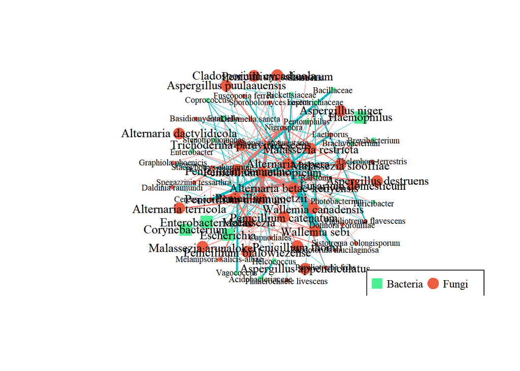

```r
filter.bib<-paste(c(taxa.selec.b,ftaxa.selec.b),collapse="|")
filter.bact<-paste(taxa.bact,collapse="|")

# Personalized function

plot.net.bf<-function(net)
{
  G<-graph_from_adjacency_matrix(net$latent_network(), mode = "undirected", weighted = TRUE, diag = FALSE)
  igraph::V(G)$label <- colnames(net$latent_network())
  G <- delete_vertices(G, which(degree(G) == 0))

  igraph::V(G)$label.cex <-ifelse(str_detect(igraph::V(G)$label,filter.bib),1,0.7)
  igraph::V(G)$size <- ifelse(str_detect(igraph::V(G)$label,filter.bib),12,4)
  igraph::V(G)$label.color <- "black"
  igraph::V(G)$shape <- ifelse(str_detect(igraph::V(G)$label,filter.bact),"square","circle")
  igraph::V(G)$color <- ifelse(str_detect(igraph::V(G)$label,filter.bact),"seagreen2","tomato2")
  igraph::V(G)$frame.color <- NA

  igraph::E(G)$color <- ifelse(igraph::E(G)$weight > 0, "#F8766D", "#00BFC4") # positivo rojo, negativo azul
  igraph::E(G)$width <- 15*abs(igraph::E(G)$weight)
  igraph::E(G)$weight<-abs(igraph::E(G)$weight)

  l <- qgraph.layout.fruchtermanreingold(get.edgelist(G,names=FALSE),vcount=vcount(G),
                                         area=80*(vcount(G)^2),repulse.rad=(vcount(G)^2.9))
  plot(G,layout=l)
  par(family = "serif")
  legend(x=.9,y=-0.9,legend=c("Bacteria","Fungi"),cex=0.9,pt.cex=2,
         col=c("seagreen2","tomato2"),pch=c(22,19),pt.bg=c("seagreen2","tomato2"),horiz=T)
  invisible(G)
}

plot.net.bf(patients.net)
```

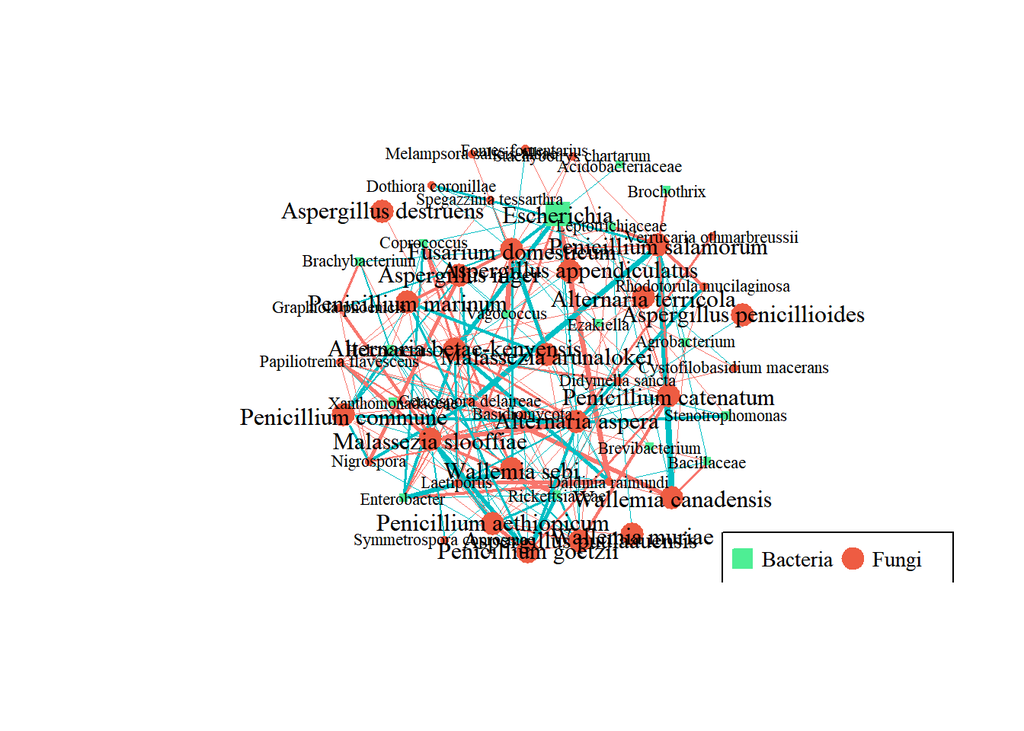

```r
plot.net.bf(controls.net)
```